# Forecasting Canyon Lake Storage: Why ARIMA Outperforms for Water Supply Planning

### STL Decomposition

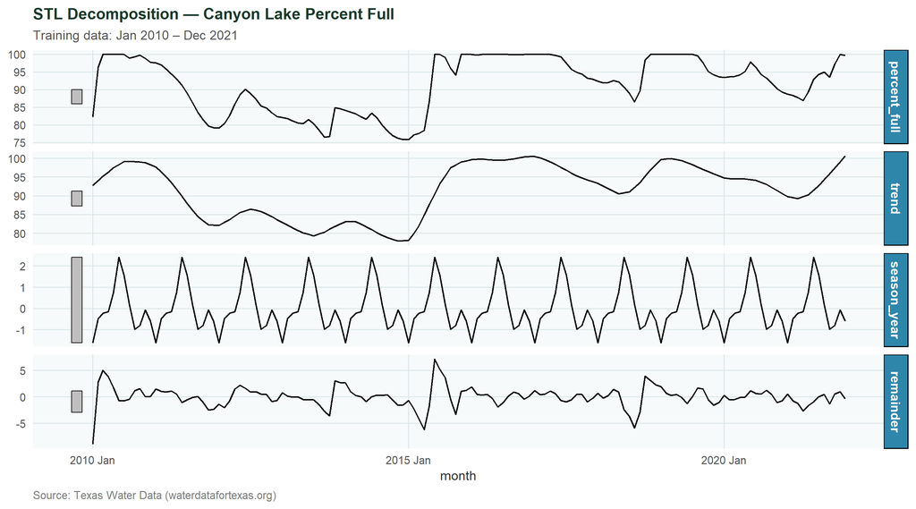

```r
train_data %>%
  model(STL(percent_full ~ trend(window = 13) +
              season(window = "periodic"))) %>%
  components() %>%
  autoplot() +
  labs(
    title    = "STL Decomposition — Canyon Lake Percent Full",
    subtitle = "Training data: Jan 2010 – Dec 2021",
    caption  = "Source: Texas Water Data (waterdatafortexas.org)"
  )
```

### Transformation & Stationarity Checks

```r
# Box-Cox lambda (assessed but not applied due to bounded variable)
lambda <- train_data %>%
  features(percent_full, features = guerrero) %>%
  pull(lambda_guerrero)
cat("Guerrero lambda:", round(lambda, 3), "\n")
```

```
## Guerrero lambda: 0.516
```

```r
# Seasonal differencing
train_data %>% features(percent_full, unitroot_nsdiffs)
```

| nsdiffs |
| --- |
| 0 |

```r
# Non-seasonal differencing after seasonal diff
train_data %>% features(difference(percent_full, 12), unitroot_ndiffs)
```

| ndiffs |
| --- |
| 0 |

# Model Fitting

```r
models <- train_data %>%
  model(
    ETS_Auto   = ETS(percent_full),
    ARIMA_Auto = ARIMA(percent_full),
    TSLM       = TSLM(percent_full ~ trend() + season()),
    Ensemble   = (ETS(percent_full) + ARIMA(percent_full) +
                    TSLM(percent_full ~ trend() + season())) / 3
  )
```

### Model Summaries

```r
report(models$ETS_Auto[[1]])
```

```
## Series: percent_full
## Model: ETS(M,Ad,N)
##   Smoothing parameters:
##     alpha = 0.9998999
##     beta  = 0.4551355
##     phi   = 0.8
##
##   Initial states:
##      l[0]     b[0]
##  68.87447 13.65154
##
##   sigma^2:  6e-04
##
##      AIC     AICc      BIC
## 961.4493 962.0624 979.2682
```

```r
report(models$ARIMA_Auto[[1]])
```

```
## Series: percent_full
## Model: ARIMA(0,1,1)
##
## Coefficients:
##          ma1
##       0.5883
## s.e.  0.0824
##
## sigma^2 estimated as 4.751:  log likelihood=-314.04
## AIC=632.09   AICc=632.17   BIC=638.01
```

```r
report(models$TSLM[[1]])
```

```
## Series: percent_full
## Model: TSLM
##
## Residuals:
##      Min       1Q   Median       3Q      Max
## -14.4549  -5.9983  -0.2996   6.5164  12.7362
##
## Coefficients:
##                Estimate Std. Error t value Pr(>|t|)
## (Intercept)    85.67585    2.44817  34.996  < 2e-16 ***
## trend()         0.05869    0.01546   3.797 0.000223 ***
## season()year2   1.15194    3.13717   0.367 0.714070
## season()year3   1.42267    3.13728   0.453 0.650960
## season()year4   1.49392    3.13747   0.476 0.634758
## season()year5   2.37826    3.13774   0.758 0.449841
## season()year6   4.00375    3.13808   1.276 0.204263
## season()year7   3.15510    3.13850   1.005 0.316612
## season()year8   1.74855    3.13900   0.557 0.578450
## season()year9   0.56015    3.13957   0.178 0.858671
## season()year10  0.75590    3.14022   0.241 0.810153
## season()year11  1.53278    3.14094   0.488 0.626364
## season()year12  1.02345    3.14174   0.326 0.745125
## ---
## Signif. codes:  0 '***' 0.001 '**' 0.01 '*' 0.05 '.' 0.1 ' ' 1
##
## Residual standard error: 7.684 on 131 degrees of freedom
## Multiple R-squared: 0.1169,  Adjusted R-squared: 0.03602
## F-statistic: 1.445 on 12 and 131 DF, p-value: 0.1535
```

# Residual Diagnostics

```r
# ARIMA residuals — styled (poster chart)
resid_plot <- models %>%
  select(ARIMA_Auto) %>%
  gg_tsresiduals(lag = 24) %>%
  invisible()
```

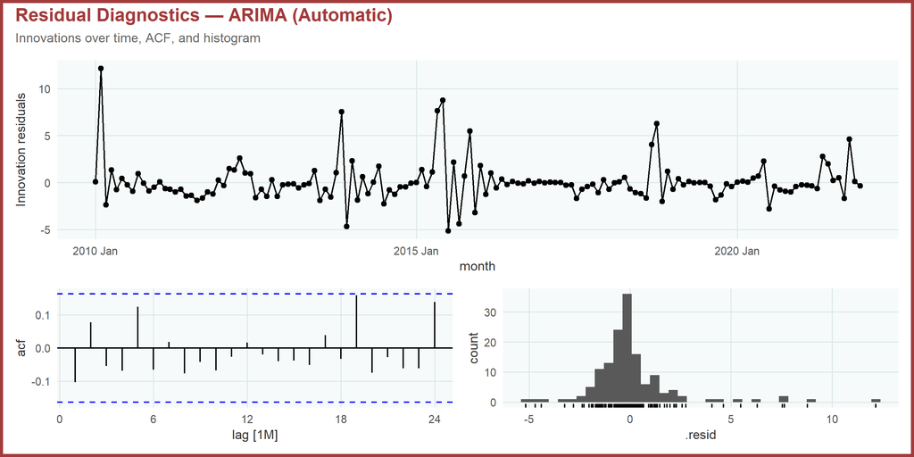

```r
p1 <- resid_plot[[1]] + theme_canyon(accent_color = "#A23B3B") + labs(title = NULL)
p2 <- resid_plot[[2]] + theme_canyon(accent_color = "#A23B3B") + labs(title = NULL)
p3 <- resid_plot[[3]] + theme_canyon(accent_color = "#A23B3B") + labs(title = NULL)

(p1 / (p2 | p3)) +
  plot_layout(heights = c(1.5, 1)) +
  plot_annotation(
    title    = "Residual Diagnostics \u2014 ARIMA (Automatic)",
    subtitle = "Innovations over time, ACF, and histogram",
    theme = theme(
      plot.title      = element_text(size = 13, face = "bold", color = "#A23B3B"),
      plot.subtitle   = element_text(size = 9,  color = "#666666"),
      plot.background = element_rect(fill = "white", color = "#A23B3B", linewidth = 2)
    )
  )
```

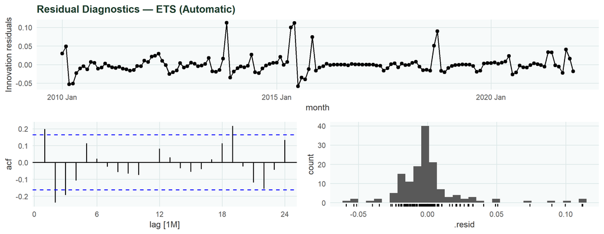

```r
models %>%
  select(ETS_Auto) %>%
  gg_tsresiduals(lag = 24) +
  labs(title = "Residual Diagnostics — ETS (Automatic)")
```

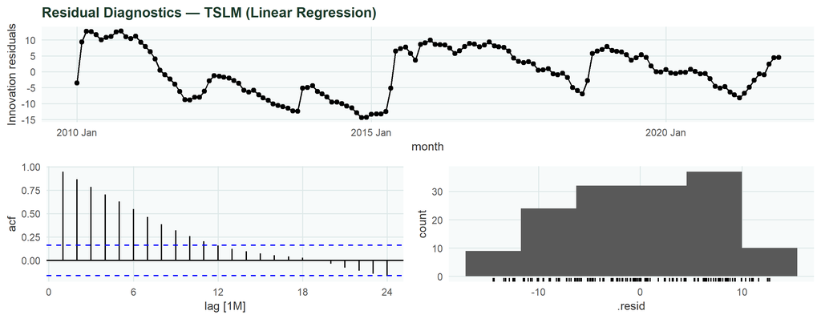

```r
models %>%
  select(TSLM) %>%
  gg_tsresiduals(lag = 24) +
  labs(title = "Residual Diagnostics — TSLM (Linear Regression)")
```

### Ljung-Box Test

```r
models_list <- c("ETS_Auto", "ARIMA_Auto", "TSLM")

ljung_results <- augment(models) %>%
  filter(.model %in% models_list) %>%
  group_by(.model) %>%
  features(.innov, ljung_box, lag = 24, dof = 0)

ljung_results %>%
  rename(Model = .model,
         `LB Statistic` = lb_stat,
         `p-value` = lb_pvalue) %>%
  mutate(
    `LB Statistic` = round(`LB Statistic`, digits = 2),
    `p-value` = round(`p-value`, digits = 3),
    `Residuals Clean?` = ifelse(`p-value` > 0.05, "Yes", "No"))
```

| Model | LB Statistic | p-value | Residuals Clean? |
| --- | --- | --- | --- |
| ARIMA_Auto | 20.16 | 0.688 | Yes |
| ETS_Auto | 48.14 | 0.002 | No |
| TSLM | 627.02 | 0.000 | No |

> **Interpretation:** A p-value above 0.05 indicates residuals are consistent with white noise. ARIMA passes (p = 0.688); ETS and TSLM show significant residual autocorrelation.

# Forecasting

```r
fc <- forecast(models, h = 36)
```

## Forecast Plot

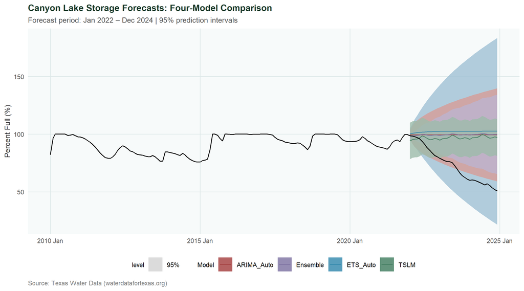

```r
fc %>%
  autoplot(canyon_monthly, level = 95, alpha = 0.8) +
  scale_color_manual(values = model_colors) +
  scale_fill_manual(values  = model_colors) +
  labs(
    title    = "Canyon Lake Storage Forecasts: Four-Model Comparison",
    subtitle = "Forecast period: Jan 2022 – Dec 2024 | 95% prediction intervals",
    caption  = "Source: Texas Water Data (waterdatafortexas.org)",
    y = "Percent Full (%)", x = NULL, color = "Model", fill = "Model"
  )
```

# Forecast Accuracy

```r
accuracy_table <- fc %>%
  accuracy(test_data) %>%
  select(.model, RMSE, MAE, MAPE) %>%
  arrange(RMSE)

accuracy_table %>%
  rename(Model = .model) %>%
  mutate(across(c(RMSE, MAE), ~ round(.x, 2)),
         MAPE = paste0(round(MAPE, 1), "%"))
```

| Model | RMSE | MAE | MAPE |
| --- | --- | --- | --- |
| TSLM | 28.45 | 24.31 | 39% |
| ARIMA_Auto | 30.39 | 26.35 | 42% |
| Ensemble | 30.59 | 26.43 | 42.2% |
| ETS_Auto | 33.00 | 29.10 | 46% |

# Model Selection & Justification

Although TSLM produced the lowest RMSE (28.5), its Ljung-Box p-value of approximately 0 indicates very autocorrelated residuals. This invalidates its prediction intervals, making it unreliable for contractual planning purposes where uncertainty bounds matter as much as point forecasts.

**The ARIMA model is selected as the best model** based on the combination of:

- Competitive forecast accuracy (RMSE = 30.4, MAE = 26.4, MAPE = 42.0%)
- Clean residuals confirmed by Ljung-Box test (p = 0.688)
- Statistically valid 95% prediction intervals suitable for drought-stage planning

For a water utility negotiating multi-year supply agreements under GBRA’s tiered drought contingency framework, the lower bound of the forecast range is operationally critical. ARIMA is the only model that produces trustworthy uncertainty estimates.

# References

City of Kyle. (2022). *About Kyle water.* City of Kyle Water Utilities. https://www.cityofkyle.gov/city-services/water-utilities/about-kyle-water/

Guadalupe-Blanco River Authority. (2024). *Drought contingency plan for wholesale customers.* https://www.gbra.org/wp-content/uploads/2024/05/2024-Wholesale-Drought-Contingency-Plan_FINAL-w-Resolution.pdf

Hyndman, R. J., & Athanasopoulos, G. (2021). *Forecasting: Principles and practice* (3rd ed.). OTexts. https://otexts.com/fpp3/

Rohli, E., Woolsey, N., & Sathiaraj, D. (2023). Near-term forecasting of water reservoir storage capacities using long short-term memory. *Environmental Data Science, 2*, e30. https://doi.org/10.1017/eds.2023.25

Stark, S. (2025, May 14). City of Kyle diversifying water sources amid pervasive drought conditions. *KXAN Austin.* https://www.kxan.com/news/local/hays/kyle/city-of-kyle-diversifying-water-sources-amid-pervasive-drought-conditions/

Water Data for Texas. (2024). *Canyon Lake reservoir storage data.* https://www.waterdatafortexas.org/reservoirs/individual/canyon